# Overview of scrattch.hicat

Zizhen Yao, Cindy van Velthoven, Adriana Sedeno-Cortes, Changkyu Lee, Lawrence Huang

2020-02-20

`scrattch.hicat` offers functions to perform iterative clustering for single cell RNAseq datasets.

The `scrattch.hicat` package is one component of the scrattch suite of packages for `S`ingle `C`ell `R`NA-seq `A`nalysis for `T`ranscriptomic `T`ype `CH`aracterization from the Allen Institute. `hicat` stands for `H`ierarchical, `I`terative `C`lustering for `A`nalysis of `T`ranscriptomics.

The pipeline consists of the following key steps:

- Dataset formatting and setup
- Parameter specification
- Iterative Clutering
  - High variance gene selection
  - Dimensionality reduction using PCA or WGCNA
  - Dimension filtering based on QC correlation
  - Jaccard-Louvain or hierarchichal (Ward) clustering
- Cluster merging based on presence of differentially expressed genes

This process is iteratively repeated within each resulting cluster until no more clusters meet differential gene expression and cluster size termination criteria.

We can inspect and visualize the results of consensus clustering:

- Compute marker genes and plot marker heatmaps
- Hierarchical dendrograms
- t-SNE plots

Consensus clustering was introduced to ensure robustness of clustering:

- Bootstrapping of the iterative clustering process
- Breakdown of consensus clustering

For this vignette, we use a subset of the dataset published in [Tasic, et al. (2016) Nature Neuroscience](https://www.ncbi.nlm.nih.gov/pmc/articles/PMC4985242/), which is available in the [tasic2016data package](https://github.com/AllenInstitute/tasic2016data):

```r
if(!"tasic2016data" %in% rownames(installed.packages())) {
  devtools::install_github("AllenInstitute/tasic2016data")
}
library(tasic2016data)
```

This vignette depends on a few other packages, in addition to `scrattch.hicat`:

```r
library(dendextend)
library(matrixStats)
library(Matrix)
library(scrattch.hicat)
```

## Dataset formatting and setup

First prepare the datasets

```r
# Load sample annotations (anno)
anno <- tasic_2016_anno

# Make a data.frame of unique cluster id, type, color, and broad type
ref.cl.df <- as.data.frame(unique(anno[,c("primary_type_id", "primary_type_label", "primary_type_color", "broad_type")]))

# Standardize cluster annoation with cluster_id, cluster_label and cluster_color. These are the required fields to visualize clusters properly.
colnames(ref.cl.df)[1:3] <- c("cluster_id", "cluster_label", "cluster_color")

# Sort by cluster_id
ref.cl.df <- ref.cl.df[order(ref.cl.df$cluster_id),]
row.names(ref.cl.df) <- ref.cl.df$cluster_id

ref.cl <- setNames(factor(anno$primary_type_id), anno$sample_name)
```

Convert counts to CPM and take log2 transformation

```r
norm.dat <- log2(cpm(tasic_2016_counts)+1)
```

If you have a very large matrix, we recommend you convert it to a sparse matrix using the Matrix package to save memory:

```r
norm.dat <- Matrix(cpm(tasic_2016_counts), sparse = TRUE)

norm.dat@x <- log2(norm.dat@x+1)
```

For this demo, we’ll select a small subset of CGE-derived interneurons for clustering. This gives us a set of 284 single-cell transcriptomic profiles to work with.

```r
select.cells <- with(anno, sample_name[primary_type_label!="unclassified" & grepl("Igtp|Ndnf|Vip|Sncg|Smad3",primary_type_label)])
```

Back to top

## Parameter specification

The final number of clusters produced by this iterative clustering algorithm is largely determined by the required cell type resolution specified by the user. The cell type resolution is defined by differential expression (DE) criteria between every pair of clusters. The users can specify these criteria ahead of time, for reuse in hicat functions by using the `de_param()` function.

We compute statistical singificance of DE genes using `limma`, with two key parameters specified below:  
**padj.th**: adjusted p value threshold for DE genes.  
**lfc.th**: log2 fold change threshold for DE genes.

We also require DE genes to have a relatively binary (on/off) expression pattern, specified by the following parameters:  
**low.th**: The minimum value used to determine whether a gene is detected in a given cell or not. This threshold is applied to log2-transformed, normalized data. The default value is 1. Users can specifiy different thresholds for different genes if necessary.  
For every pair of clusters (one as foreground, and the other as background), we define q1, and q2 as the proportion of cells with expression > **low.th** in the foregound and background cluster respectively.  
**q1.th**: For up regulated genes, q1 should be greater than q1.th in the *foreground* set.  
**q2.th**: For up regulated genes, q2 should be smaller than q2.th in the *background* set.  
**q.diff.th**: The difference, defined as abs(q1 - q2)/max(q1, q2) should be greater than q.diff.th.  
By default, **q1.th** = 0.5, **q2.th** = NULL, and **q.diff.th** = 0.7.

The user can also ignore these parameters by setting them all to NULL.  
For high-depth datasets, like those generated using SMARTerV4 or Smart-Seq2, we recommend starting with **q1.th** = 0.5 .  
For low-depth datasets, like those generated using Dropseq or 10X Genomics, we recommend starting with **q1.th** = 0.3 due to the generally lower gene detection per cell in these datasets.  
When focusing on discrete cell types, set **q.diff.th** closer to 1.  
If splitting cell types based on graded gene expression variation is of interest, adjust **q.diff.th** closer to 0.

To determine whether two clusters are seperable based on DE genes, we define **de.score** as the sum of -log10(adjusted Pvalue) for all DE genes. Each gene contributes at most 20 towards the sum. All clusters should have pairwise de.score greater than **de.score.th**.  
For small datasets (#cells < 1000), we recommend **de.score.th** = 40.  
For large datasets (#cells > 10000), we recommend **de.score.th** = 150.

```r
de.param <- de_param(padj.th     = 0.05,
                     lfc.th      = 1,
                     low.th      = 1,
                     q1.th       = 0.5,
                     q.diff.th   = 0.7,
                     de.score.th = 40)
```

Back to top

## Perform clustering

`scrattch.hicat` can perform clustering using WGCNA or PCA for dimensionality reduction. WGCNA mode is good for detecting rare clusters and provides cleaner cluster boundaries, while PCA is more scalable to large datasets, captures combinatorial marker expression patterns more effectively, and is more sensitive to low-depth datasets.

We recommend using WGCNA for smaller, high-depth datasets (< 4,000 samples; > 5,000 genes detecter per sample), and PCA for large or low-coverage datasets (> 4,000 samples or < 5,000 genes detected per sample). Another consideration is that WGCNA is considerably slower than PCA. Note that while the whole clustering pipeline scales quite well with the number of cells, the running time heavily depends on the cell type complexity as clustering is iterative.

First, let us just run one round of clustering using WGCNA mode using high stringency to check the broad cell types

```r
onestep.result <- onestep_clust(norm.dat,
                               select.cells = select.cells,
                               dim.method = "WGCNA",
                               de.param = de_param(de.score.th=500))
```

```
##  ..done.
##   Finding nearest neighbors...DONE ~ 0.03 s
##   Compute jaccard coefficient between nearest-neighbor sets...DONE ~ 0.02 s
##   Build undirected graph from the weighted links...DONE ~ 0.03 s
##   Run louvain clustering on the graph ...DONE ~ 0.03 s
##   Return a community class
##   -Modularity value: 0.756382
##   -Number of clusters: 10
```

Take a quick look at the clustering heatmap

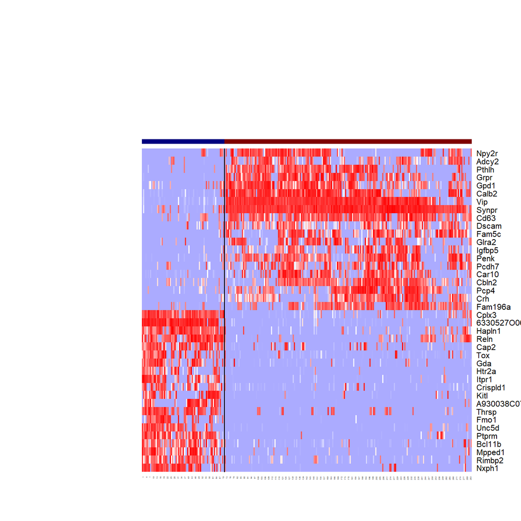

```r
display.result = display_cl(onestep.result$cl, norm.dat, plot=TRUE, de.param=de.param)
```

Apply iterative clustering pipeline for finer splits based on existing clusters using more relaxed threshold.

```r
WGCNA.clust.result <- iter_clust(norm.dat,
                               select.cells = select.cells,
                               dim.method = "WGCNA",
                               de.param = de.param,
                               result=onestep.result)
```

You can apply iterative clustering pipeline from scratch.

```r
WGCNA.clust.result <- iter_clust(norm.dat,
                               select.cells = select.cells,
                               dim.method = "WGCNA",
                               de.param = de.param)
```

Back to top

## Eliminate technical artfacts at dimension reduction state

Technical variation that should be masked during the clustering process can be specified using a matrix that we term **rm.eigen**. If batch effects are present, you can use the first principle component of batch-specific genes as a column in **rm.eigen**.

QC-related factors, such as sequencing depth, gene detection limits, and fraction of reads mapped to transcriptome also tend to correlate with systemetic technical variation in gene expression.  
You can directly use proper transformation of these QC-related variables, or use the first principle component of the genes that correlate with these QC factors. The latter approach tends to work better with real datasets. When **rm.eigen** is specified, any reduced-dimension vectors during clustering that have correlation greater than **rm.th** with any columns of **rm.eigen** are ignored during clustering.

We recommend that users to first explore their data by running the clustering pipeline without setting **rm.eigen**. If any batch specific or QC-driven clusters appear to cause problems, the user can create **rm.eigen** as demonstrated below, and rerun the pipeline.

```r
gene.counts <- colSums(norm.dat > 0)
rm.eigen <- matrix(log2(gene.counts), ncol = 1)
row.names(rm.eigen) <- names(gene.counts)
colnames(rm.eigen) <- "log2GeneCounts"
```

```r
WGCNA.clust.result <- iter_clust(norm.dat,
                               select.cells = select.cells,
                               dim.method = "WGCNA",
                               de.param = de.param,
                               rm.eigen = rm.eigen)
```

Back to top

## Cluster merging based on presence of differentially expressed genes

Throughout the iterative clustering process performed by `iter_clust()`, the function checked whether clusters at any iteration can be seperated by DEG. However, clusters from different iterations can end up very similar. Thus, it is necessary to check whether all the clusters are seperable by DEGs in the end. Clusters are merged in an order defined by the pairs of clusters that are nearest neighbors, which are computed in a reduced dimension space defined by **rd.dat**.

Here, we use the set of markers produced by `iter_clust()` to define the reduced dimensions:

```r
WGCNA.merge.result <- merge_cl(norm.dat,
                         cl = WGCNA.clust.result$cl,
                         rd.dat = t(norm.dat[WGCNA.clust.result$markers, select.cells]),
                         de.param = de.param)
```

Alternatively, the transpose of rd.dat could be specified as “rd.dat.t”:

```r
WGCNA.merge.result <- merge_cl(norm.dat,
                         cl = WGCNA.clust.result$cl,
                         rd.dat.t = norm.dat[WGCNA.clust.result$markers, select.cells],
                         de.param = de.param)
```

Back to top

## Compare and annotate clusters against reference cluster annotation

In this demo, we have previously derived cluster labels from Tasic, et al. (2016). To see how these cluster calls match up to those generated by `scrattch.hicat`, we can compare and annotate the clusters based on the reference cluster annotation.

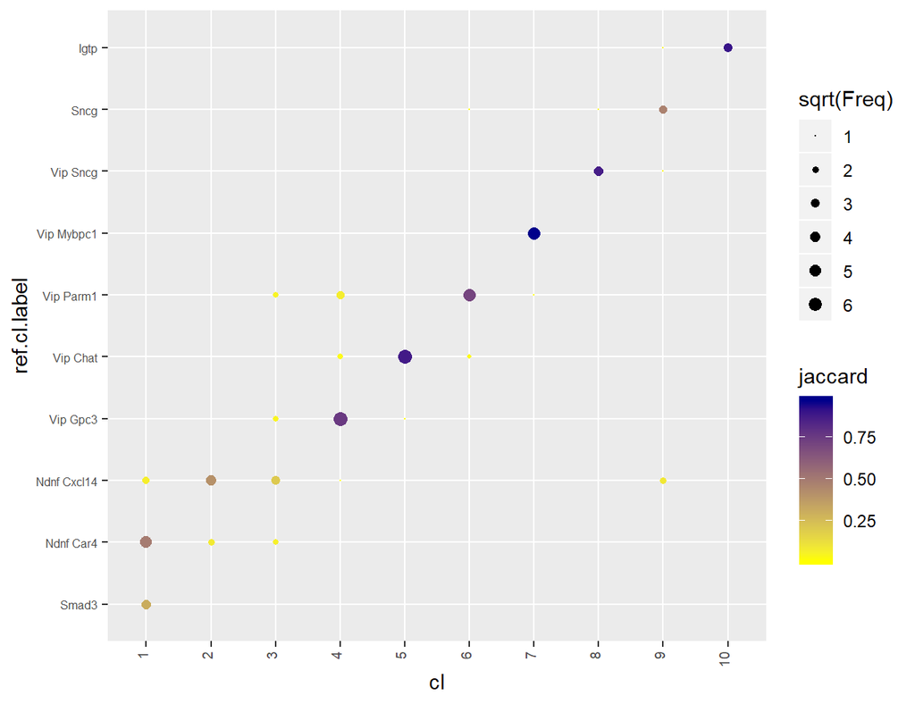

Note that the clustering differs slightly from the reference clusters. Particularly, the original Ndnf Cxcl14 is split into two clusters, and one of this cluster also contain cells from Vip Gpc3 cluster. Based on analysis based on a bigger dataset, we know that the cell type diversities for CGE-derived interneurons are richer than what we described here, and this clustering analysis is far from saturation due to small number of cells.

Now Let’s compute DE genes between every pair of clusters. To generate the heatmap, use the top 20 DE genes by default. If you have many clusters, the heatmap can be too large to display. The users may choose different “n.markers”

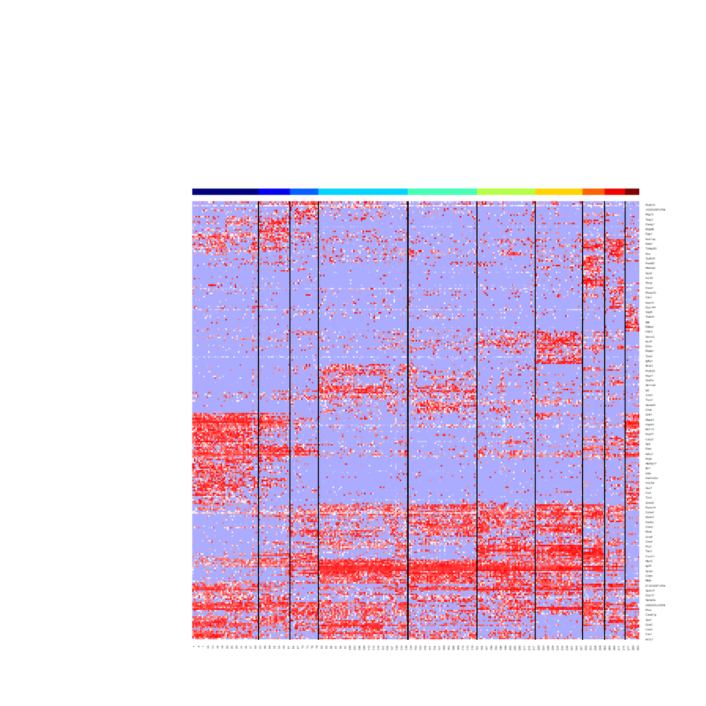

```r
display.result = display_cl(cl, norm.dat, plot=TRUE, de.param=de.param, min.sep=4, n.markers=20)
```

```r
de.genes= display.result$de.genes
```

At this point, check the clusters manually to determine if some clusters are outliers. Define cl.clean as the clusters after removing outliers.

```r
cl.clean <- droplevels(cl)
```

We find it helpful to use hierarchical structure to categorize cell types at different resolution. To build dendrogram, we use cluster-cluster correlation matrix based on cluster medians of the top 50 genes between every pair of clusters with `select_markers()` and `build_dend()`. The confidence of each branch point can be estimated by bootstrap approach implemented by pvclust package, which is encapsulated by `build_dend()`.

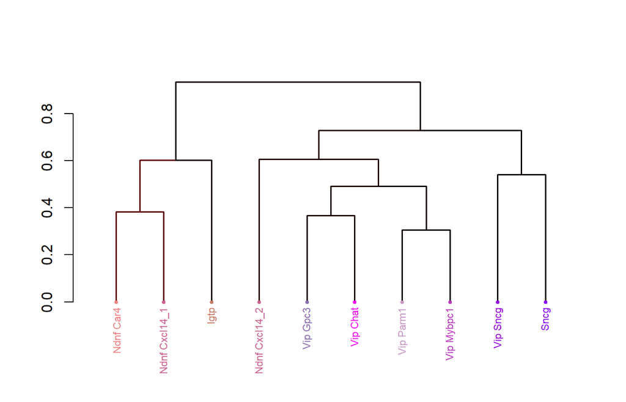

```r
select.markers = select_markers(norm.dat, cl.clean, de.genes=de.genes,n.markers=50)$markers
cl.med <- get_cl_medians(norm.dat[select.markers,], cl)
##The prefered order for the leaf nodes.
l.rank <- setNames(1:nrow(cl.df), row.names(cl.df))
##Color of the leaf nodes.
l.color <- setNames(as.character(cl.df$cluster_color), row.names(cl.df))
dend.result <- build_dend(cl.med[,levels(cl.clean)],
                          cl.cor=NULL,
                          l.rank,
                          l.color,
                          nboot = 100)
dend <- dend.result$dend
###attach cluster labels to the leafs of the tree
dend.labeled = dend
labels(dend.labeled) <- cl.df[labels(dend), "cluster_label"]
plot(dend.labeled)
```

Reorder the clusters based on the dendrogram:

```r
cl.clean <- setNames(factor(as.character(cl.clean), levels = labels(dend)), names(cl.clean))
cl.df.clean <- cl.df[levels(cl.clean),]
```

Plot cluster-cluster correlation matrix:

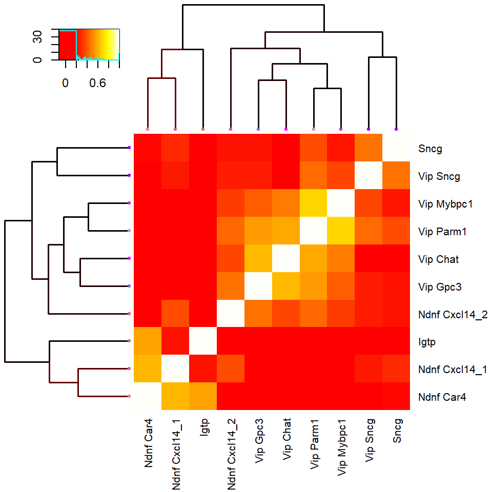

```r
cl.cor <- dend.result$cl.cor
row.names(cl.cor) <- colnames(cl.cor) <- cl.df[row.names(cl.cor), "cluster_label"]
heatmap.3(cl.cor,
          Rowv = dend, Colv = dend,
          trace = "none", col = heat.colors(100),cexRow=0.8, cexCol=0.8,
          breaks = c(-0.2, 0.2, seq(0.2, 1, length.out = 99)))
```

Back to top

## t-SNE plots

Generate t-SNE coordinates and a plot using `plot_tsne_cl()`:

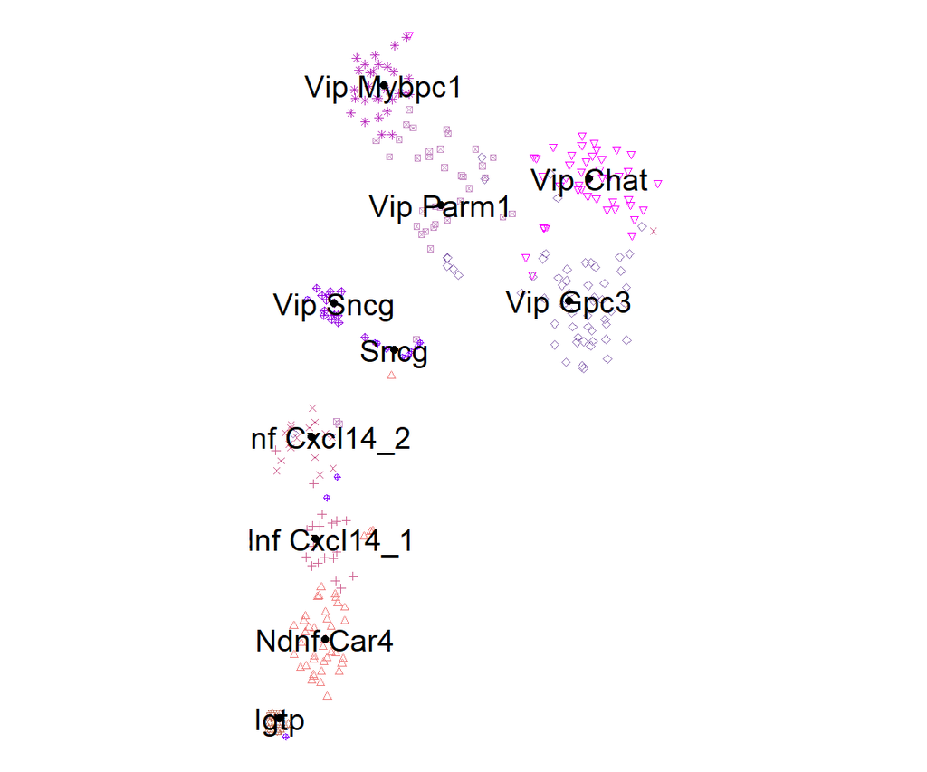

```r
tsne.result <- plot_tsne_cl(norm.dat, select.markers, cl, cl.df, fn.size=5, cex=1)
tsne.df = tsne.result$tsne.df
tsne.result$g
```

Plot expression of a set of genes using the t-SNE coordinates with `plot_tSNE_gene()`:

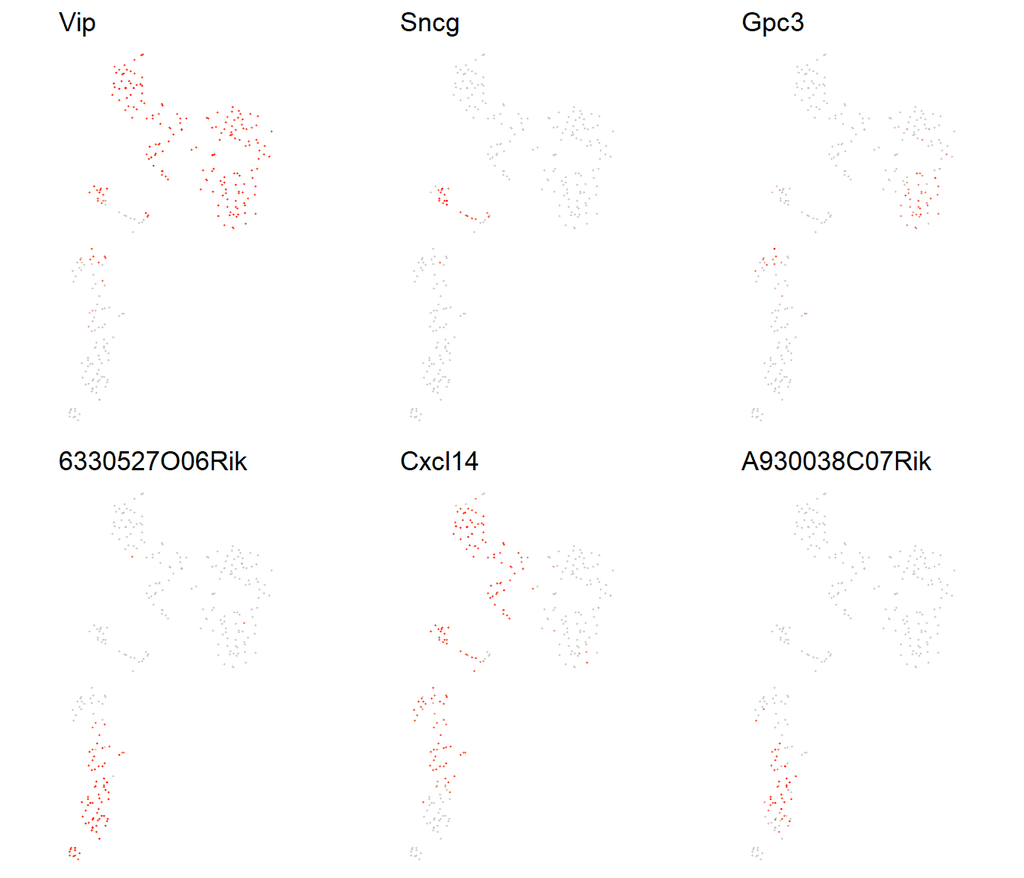

```r
tsne.df <- tsne.result$tsne.df
## 6330527O06Rik is alias for Lamp5, and A930038C07Rik is alais for Ndnf
markers <- c("Vip","6330527O06Rik","Sncg","Cxcl14","Gpc3","A930038C07Rik")
gene.plots <- plot_tSNE_gene(tsne.df, norm.dat, markers)
multiplot(plotlist = gene.plots, cols = 3)
```

Back to top

## Bootstrapping for Consensus clustering

The iterative clustering pipeline tends to produce many clusters, with increased uncertainty as we try to split the clusters at finer resolution. Therefore, it is important to assess the robustness of clustering results. We address this problem by performing clustering many times on 80% of randomly subsampled cells, keep track of how often each cell is clustered with each other cell (a cell-cell co-clustering matrix), and use these frequencies of cell-cell co-clustering to infer consensus clustering. We also compute statistics to evaluate our confidence in the seperation between every pair of consensus clusters. `run_consensus_clust()` is a convenient wrapper function for performing this bootstrapped, iterative clustering process. For faster execution, we use “PCA” mode.

If you have a multi-core computer, this function can be run in parallel by setting **mc.cores** to the number of cores you can use.  
Note that this can result in high memory consumption with a high number of parallel processes. Try using small number of cores first to monitor the memory consumption:

```r
result <- run_consensus_clust(norm.dat,
                              niter = 20,
                              de.param = de.param,
                              rm.eigen = rm.eigen,
                              dim.method = "PCA",
                              output_dir = "subsample_PCA",
                              mc.cores = 4)
```

Compare the consensus clustering results against the reference clusters, and we see that PCA mode produce clusters at lower resolution than WGCNA mode. Small clusters like Igtp, which has very distinct transcriptional signature, still got merged with other clusters.

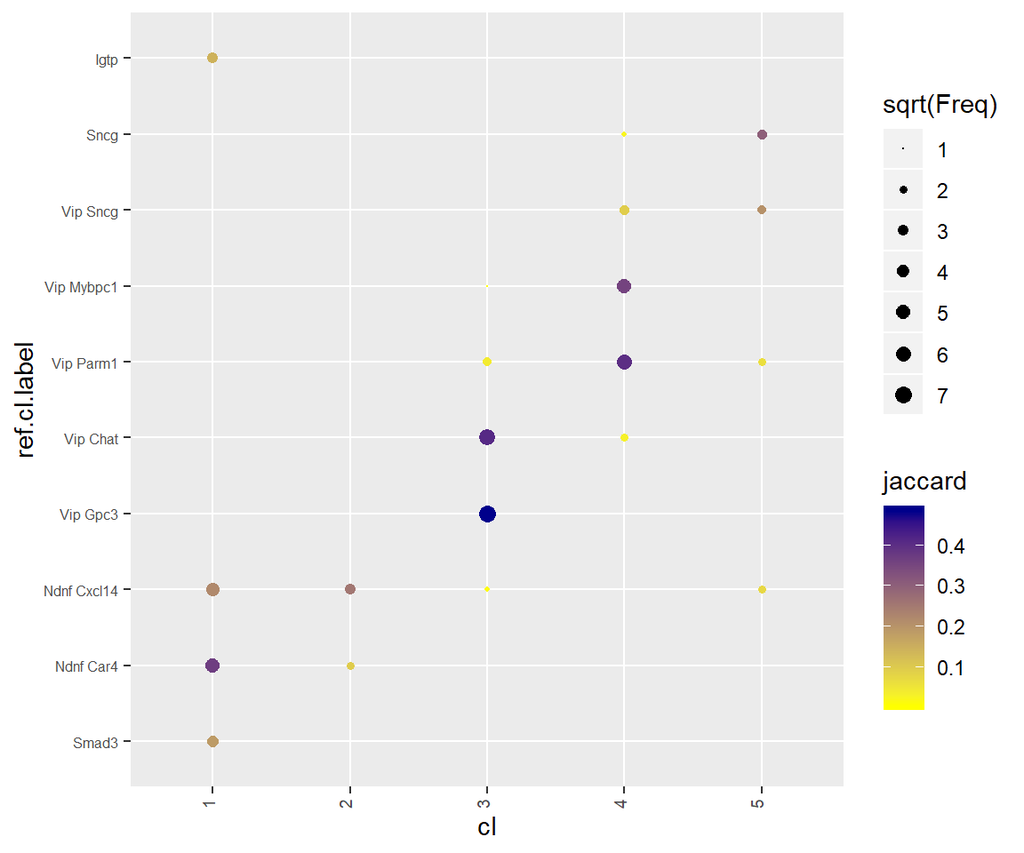

Back to top

## Breakdown of consensus clustering

`run_consensus_clust()` is a wrapper function that performs the following steps:

- Perform clustering on subsampled cells:

```r
d <- paste0("subsample_PCA")
dir.create(d)
n_iter <- 10
all.cells <- select.cells
subsample.result <- sapply(1:n_iter,
                           function(i) {
                             prefix <- paste0("iter",i)
                             tmp.cells <- sample(all.cells, round(0.8 * length(all.cells)))
                             result <- iter_clust(norm.dat,
                                                  select.cells = tmp.cells,
                                                  prefix = prefix,
                                                  dim.method = "PCA",
                                                  de.param = de.param)
                             save(result, file = file.path(d, paste0("result.", i, ".rda")))
                           }
)
```

- Collect cell-cell co-clustering probablities:

```r
result.files <- file.path(d, dir(d, "result.*.rda"))
co.result <- collect_subsample_cl_matrix(norm.dat, result.files, all.cells)
```

- Infer consensus clusters based on the cell-cell co-clustering matrix:

```r
consensus.result <- iter_consensus_clust(cl.list = co.result$cl.list,
            cl.mat = co.result$cl.mat, norm.dat = norm.dat, select.cells = all.cells,
            de.param = de.param, merge.type = "directional", method = "auto",
            result = NULL)
```

- Adjust cluster boundaries to optimize within-cluster co-clustering probabilties:

```r
refine.result <- refine_cl(consensus.result$cl,
                           cl.mat = co.result$cl.mat,
                           tol.th = 0.01,
                           confusion.th = 0.8,
                           min.cells = de.param$min.cells)
```

- Double-check if all clusters are separable based on DE genes again:

```r
merge.result <- merge_cl(norm.dat,
                         refine.result$cl,
                         rd.dat.t = norm.dat[consensus.result$markers,select.cells],
                         de.param = de.param,
                         merge.type = "directional",
                         return.markers = FALSE)
```

Back to top